# Hogan CKMRSIM

## Make Figure 2.

Here we create Fig. 2 - the plot with mhap heterozygosity and best snp minor allele frequency per locus.

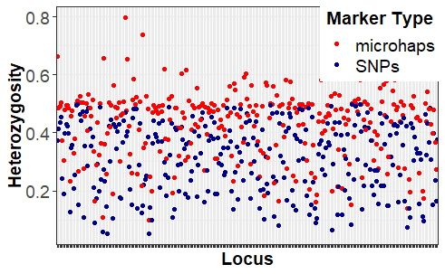

Now, we are going to make our CKMR-ready allele frequencies for each of our four data sets in a named list:

### Making a list of data sets

```r
fourData_list_13 <- list(
  m165_13 = mhaps_13_filter,
  s165_13 = best_snps_165_13,
  m96_13 = mhaps_13_filter %>% filter(Locus %in% top_mhaps_13$Locus),
  s96_top_13 = best_snps_165_13 %>% filter(Locus %in% top_snps_96_all_13$Locus)
)
```

## Doing CKMR calcs on each data set

We can do each step, lapplying over things:

```r
CK_list_13 <- lapply(fourData_list_13, function(x)
  create_ckmr(x, kappa_matrix = kappas[c("PO", "FS", "HS", "U"), ])
)
```

And simulate the Qij values. Do 10^5…

```r
Qs_list_13 <- lapply(CK_list_13, function(x)
  simulate_Qij(C = x, froms = c("PO", "FS", "HS", "U"), tos = c("PO", "FS", "HS", "U"), reps = 10^5)
)
```

```
Simulating unlinked markers from Y_l_true matrices for relationship: PO
Simulating unlinked markers from Y_l_true matrices for relationship: FS
Simulating unlinked markers from Y_l_true matrices for relationship: HS
Simulating unlinked markers from Y_l_true matrices for relationship: U
Simulating unlinked markers from Y_l_true matrices for relationship: PO
Simulating unlinked markers from Y_l_true matrices for relationship: FS
Simulating unlinked markers from Y_l_true matrices for relationship: HS
Simulating unlinked markers from Y_l_true matrices for relationship: U
Simulating unlinked markers from Y_l_true matrices for relationship: PO
Simulating unlinked markers from Y_l_true matrices for relationship: FS
Simulating unlinked markers from Y_l_true matrices for relationship: HS
Simulating unlinked markers from Y_l_true matrices for relationship: U
Simulating unlinked markers from Y_l_true matrices for relationship: PO
Simulating unlinked markers from Y_l_true matrices for relationship: FS
Simulating unlinked markers from Y_l_true matrices for relationship: HS
Simulating unlinked markers from Y_l_true matrices for relationship: U
```

And once that is done, we can collect samples from it:

```r
FPRs_etc_13 <- lapply(Qs_list_13, function(x) mc_sample_simple(x, nu = c("PO", "FS", "HS"), method = "IS", FNRs = seq(0.01, 0.30, by = 0.01))) %>%
  bind_rows(.id = "marker_set")
```

And now, let us spread that into a data set that is easier to read:

```r
FPRs_etc_13 %>%
  rename(relationship = pstar) %>%
  select(relationship, FNR, marker_set, FPR) %>%
  tidyr::spread(data = ., key = marker_set, value = FPR)
```

| relationship | FNR | m165_13 | m96_13 | s165_13 | s96_top_13 |
| --- | --- | --- | --- | --- | --- |
| FS | 0.01 | 2.195887e-15 | 3.460840e-06 | 1.876598e-11 | 1.496095e-03 |
| FS | 0.02 | 3.258278e-16 | 1.188710e-06 | 2.944113e-12 | 6.377207e-04 |
| FS | 0.03 | 9.089340e-17 | 5.882258e-07 | 8.932430e-13 | 3.599764e-04 |
| FS | 0.04 | 3.446695e-17 | 3.356370e-07 | 3.534324e-13 | 2.284142e-04 |
| FS | 0.05 | 1.511497e-17 | 2.103407e-07 | 1.680074e-13 | 1.553424e-04 |
| FS | 0.06 | 7.414745e-18 | 1.413481e-07 | 8.726164e-14 | 1.108734e-04 |
| FS | 0.07 | 3.959047e-18 | 9.930589e-08 | 4.793958e-14 | 8.197275e-05 |
| FS | 0.08 | 2.267978e-18 | 7.202374e-08 | 2.796751e-14 | 6.224438e-05 |
| FS | 0.09 | 1.360910e-18 | 5.364662e-08 | 1.708684e-14 | 4.816189e-05 |
| FS | 0.10 | 8.448806e-19 | 4.077505e-08 | 1.082837e-14 | 3.791028e-05 |

[output cut: 80 more lines]

### Make Figure 3.

Let’s plot the FPRs_etc:

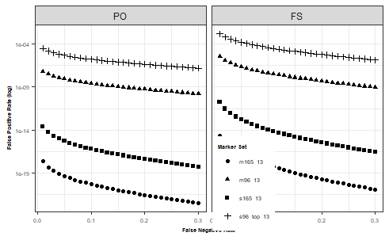

# Even

```r
dose1_14 <- PHOGAN14_postQA.gcl$scores[,,1] %>%
  as_tibble(rownames="ind") %>%
  gather(locus, dose1, -ind)
dose2_14 <- PHOGAN14_postQA.gcl$scores[,,2] %>%
  as_tibble(rownames="ind") %>%
  gather(locus, dose2, -ind)
Hogan_14_input <- left_join(dose1_14, dose2_14, by = c("ind", "locus"))
```

### Computing allele frequencies

```r
#haptidy <- hapkept %>%
#  unite(col = hap1, haplotype.1, read.depth.1) %>%
#  unite(col = hap2, haplotype.2, read.depth.2) %>%
#  gather(key = gene_copy, value = H, hap1, hap2) %>%
#  separate(H, into = c("Allele", "read_depth")) %>%
#  arrange(panel, locus, Indiv.ID, gene_copy)
haptidy_14 <- Hogan_14_input %>%
  gather(key = gene_copy, value = H, dose1, dose2) %>%
  separate(H, into = "Allele") %>%
  arrange(locus, ind, gene_copy)
```

So, now we just need to compute the frequencies for each of the haplotypes

```r
hapfreqs_14 <- haptidy_14 %>%
  group_by(locus, Allele) %>%
  summarise(count = n()) %>%
  mutate(Freq = count / sum(count))
```

## Do the CKMR sim analyses

### Get it in the right format

First we have to get that data frame in the right format and reindex the markers and make something that `CKMRsim` is expecting to be able to work with (i.e., it has haplotypes in descending frequeny at each locus and it has locus and allele indices in there). To get loci to be ordered as they are, I have to throw `Pos` in there, even though they are not known to have a position on any Chrom.

```r
mhaps_14 <- hapfreqs_14 %>%
  ungroup() %>%
  mutate(Chrom = "GTseq") %>%
  rename(Locus = locus) %>%
  select(-count) %>%
  mutate(Pos = as.integer(factor(Locus, levels = unique(Locus)))) %>%
  mutate(LocIdx = 0,
         AlleIdx = 0) %>%
  CKMRsim::reindex_markers() %>%
  select(Chrom, Locus, Pos, Allele, LocIdx, AlleIdx, Freq)
```

### Make Figure 1.

While we are at it, let’s look at the distribution of the number of alleles across loci:

```r
m_14 <- mhaps_14 %>%
  group_by(Locus) %>%
  summarise(num_haplotypes = n()) %>%
  group_by(num_haplotypes) %>%
  summarise(num_loci = n()) %>% # plot this for figure 1
  ggplot(., aes(num_haplotypes, num_loci)) +
  geom_histogram(stat = "identity") +
  theme_bw() +
  xlab("Number of Haplotypes") +
  ylab("Number of Loci") +
  scale_x_continuous(breaks = c(3,6,9,12))
```

```
Ignoring unknown parameters: binwidth, bins, pad
```

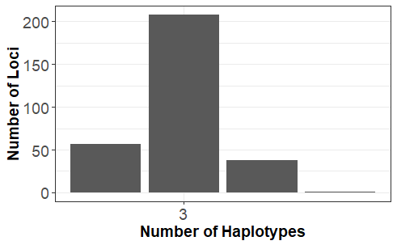

```r
fig1_14 <- m_14 + theme(
  axis.text.x=element_text(size=14),
  axis.title.x=element_text(size=14, face="bold"),
  axis.text.y=element_text(size=14),
  axis.title.y=element_text(size=14, face="bold")
)
fig1_14
```

```r
mhaps_14_filter <- mhaps_14 %>%
  filter(Allele != "0")
```

### Running through CKMRsim

First we create a CKMR object. In the current version of the CKMRsim, this assumes an error model that is appropriate to microhaps and SNPs (0.005 per gene copy per snp, scaled by the number of SNPs).

```r
CK_14 <- create_ckmr(mhaps_14_filter, kappa_matrix = kappas[c("PO", "FS", "HS", "U"), ])
```

Then we can simulate some Q values:

```r
Qs_14 <- simulate_Qij(C = CK_14, froms = c("PO", "FS", "HS", "U"), tos = c("PO", "FS", "HS", "U"), reps = 10^4)
```

```
Simulating unlinked markers from Y_l_true matrices for relationship: PO
Simulating unlinked markers from Y_l_true matrices for relationship: FS
Simulating unlinked markers from Y_l_true matrices for relationship: HS
Simulating unlinked markers from Y_l_true matrices for relationship: U
```

```r
# then do the  sampling to get the FPRs
mc_sample_simple(Qs_14, nu = "PO", de = c("U", "FS"), tr = c("U", "FS"), method = "both")
```

| FNR | FPR | se | num_nonzero_wts | Lambda_star | pstar | mc_method | numerator | denominator | true_relat |
| --- | --- | --- | --- | --- | --- | --- | --- | --- | --- |
| 0.01 | 2.305044e-19 | 2.175138e-20 | 9900 | 37.486091 | PO | IS | PO | U | U |
| 0.05 | 5.372986e-21 | 2.531457e-22 | 9500 | 42.730636 | PO | IS | PO | U | U |
| 0.10 | 6.721457e-22 | 2.587648e-23 | 9000 | 45.192038 | PO | IS | PO | U | U |
| 0.20 | 4.035182e-23 | 1.285244e-24 | 8000 | 48.369546 | PO | IS | PO | U | U |
| 0.30 | 5.056214e-24 | 1.481375e-25 | 7000 | 50.655192 | PO | IS | PO | U | U |
| 0.01 | 0.000000e+00 | NA | NA | 37.486091 | NA | vanilla | PO | U | U |
| 0.05 | 0.000000e+00 | NA | NA | 42.730636 | NA | vanilla | PO | U | U |
| 0.10 | 0.000000e+00 | NA | NA | 45.192038 | NA | vanilla | PO | U | U |
| 0.20 | 0.000000e+00 | NA | NA | 48.369546 | NA | vanilla | PO | U | U |
| 0.30 | 0.000000e+00 | NA | NA | 50.655192 | NA | vanilla | PO | U | U |

[output cut: 30 more lines]

If we want to plot the actual distributions, we can extract them and plot them. For example, to plot the PO/U Lambdas we can do:

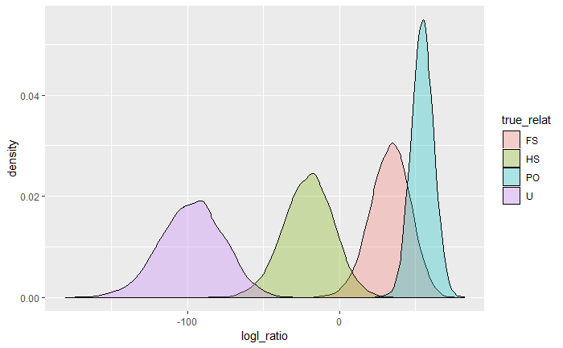

## Ranking and Selecting microhaps and SNPs

### Getting SNP frequencies

To find the SNP frequencies, we are going to need to explode those haplotypes into constituent SNPs and estimate their frequencies, and then take the best SNPs from each microhaplotype to then select subsets of them. We are going to operate on `mhaps` for this, and then get a data frame called `best_snps_165` which are the SNP allele allele frequencies. We will filter that data frame later to get our different subsets of SNPs.

```r
# get all the SNP freqs
snp_freqs_14 <- mhaps_14_filter %>%
  split(f = mhaps_14_filter$Locus) %>%
  lapply(function(x) {
    x$exploded = sapply(strsplit(x$Allele, split = ""), function(y) paste(y, collapse = "."))
    x
  }) %>%
  lapply(., function(x) {
    separate(x, exploded, into = paste("snp", 1:nchar(x$Allele[1]), sep = "_"))
  }) %>%
  lapply(., function(x) {
    gather(x, key = "SNP", value = "base", contains("snp_"))
  }) %>%
  bind_rows %>%
  group_by(Chrom, Locus, Pos, LocIdx, SNP, base) %>%
  summarise(Freq = sum(Freq))
# now, get the best (MAF closest to 0.5)
best_snps_165_14 <- snp_freqs_14 %>%
  group_by(Locus, SNP) %>%
  filter(n() > 1) %>%  # toss SNPs that are monomorphic---for some reason there are some...
  mutate(maf = min(Freq)) %>%  # since there are only two alleles, this gets the MAF at that locus
  group_by(Locus) %>%
  filter(near(maf, max(maf)))  %>%  # this almost does it, but some snps at a locus might have the same MAF at different snps
  mutate(tmp = 1:n()) %>%
  filter(tmp < 3)  %>% # this gets rid of those same MAF cases.
  select(-tmp, -maf) %>%
  rename(Allele = base) %>%
  mutate(AlleIdx = 0) %>%
  CKMRsim::reindex_markers() %>%
  select(Chrom, Locus, Pos, Allele, LocIdx, AlleIdx, Freq)
```

Now, let’s just make a quick plot to confirm that we have gotten the highest minor allele frequency SNPs for each locus.

[figure not shown]

```r
all_mafs_14 <- snp_freqs_14 %>%
  group_by(Locus, SNP) %>%
  summarise(maf = min(Freq)) %>%
  filter(maf <= 0.5)  # this gets rid of monomorphic ones
best_mafs_14 <- best_snps_165_14 %>%
  group_by(Locus) %>%
  summarise(maf = min(Freq))
ggplot(all_mafs_14, aes(y = Locus, x = maf)) +
  geom_point() +
  geom_point(data = best_mafs_14, colour = "red")
```

We will come back to these to grab the allele frequencies for further analysis.

```r
top_snps_96_all_14 <- best_mafs_14 %>%
  arrange(desc(maf)) %>%
  slice(1:96)
```

### Selecting the best microhaps

First we are going to find the microhaps with the highest heterozygosity, and the SNPs with the high MAF

```r
mhap_hz_14 <- mhaps_14_filter %>%
  group_by(Locus) %>%
  summarise(hz = 1 - sum(Freq^2), nHaps = n()) %>%
  arrange(desc(hz))
top_mhaps_14 <- mhap_hz_14 %>%
  slice(1:96)
```

## Make Figure 2.

Here we create Fig. 2 - the plot with mhap heterozygosity and best snp minor allele frequency per locus.

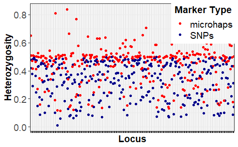

Now, we are going to make our CKMR-ready allele frequencies for each of our four data sets in a named list:

### Making a list of data sets

```r
fourData_list_14 <- list(
  m165_14 = mhaps_14_filter,
  s165_14 = best_snps_165_14,
  m96_14 = mhaps_14_filter %>% filter(Locus %in% top_mhaps_14$Locus),
  s96_top_14 = best_snps_165_14 %>% filter(Locus %in% top_snps_96_all_14$Locus)
)
```

## Doing CKMR calcs on each data set

We can do each step, lapplying over things:

```r
CK_list_14 <- lapply(fourData_list_14, function(x)
  create_ckmr(x, kappa_matrix = kappas[c("PO", "FS", "HS", "U"), ])
)
```

And simulate the Qij values. Do 10^5…

```r
Qs_list_14 <- lapply(CK_list_14, function(x)
  simulate_Qij(C = x, froms = c("PO", "FS", "HS", "U"), tos = c("PO", "FS", "HS", "U"), reps = 10^5)
)
```

```
Simulating unlinked markers from Y_l_true matrices for relationship: PO
Simulating unlinked markers from Y_l_true matrices for relationship: FS
Simulating unlinked markers from Y_l_true matrices for relationship: HS
Simulating unlinked markers from Y_l_true matrices for relationship: U
Simulating unlinked markers from Y_l_true matrices for relationship: PO
Simulating unlinked markers from Y_l_true matrices for relationship: FS
Simulating unlinked markers from Y_l_true matrices for relationship: HS
Simulating unlinked markers from Y_l_true matrices for relationship: U
Simulating unlinked markers from Y_l_true matrices for relationship: PO
Simulating unlinked markers from Y_l_true matrices for relationship: FS
Simulating unlinked markers from Y_l_true matrices for relationship: HS
Simulating unlinked markers from Y_l_true matrices for relationship: U
Simulating unlinked markers from Y_l_true matrices for relationship: PO
Simulating unlinked markers from Y_l_true matrices for relationship: FS
Simulating unlinked markers from Y_l_true matrices for relationship: HS
Simulating unlinked markers from Y_l_true matrices for relationship: U
```

And once that is done, we can collect samples from it:

```r
FPRs_etc_14 <- lapply(Qs_list_14, function(x) mc_sample_simple(x, nu = c("PO", "FS", "HS"), method = "IS", FNRs = seq(0.01, 0.30, by = 0.01))) %>%
  bind_rows(.id = "marker_set")
```

And now, let us spread that into a data set that is easier to read:

```r
FPRs_etc_14 %>%
  rename(relationship = pstar) %>%
  select(relationship, FNR, marker_set, FPR) %>%
  tidyr::spread(data = ., key = marker_set, value = FPR)
```

| relationship | FNR | m165_14 | m96_14 | s165_14 | s96_top_14 |
| --- | --- | --- | --- | --- | --- |
| FS | 0.01 | 4.011463e-16 | 6.866303e-07 | 1.846733e-11 | 1.655109e-03 |
| FS | 0.02 | 5.330860e-17 | 2.427295e-07 | 2.895514e-12 | 6.636532e-04 |
| FS | 0.03 | 1.381284e-17 | 1.196940e-07 | 8.673812e-13 | 3.637223e-04 |
| FS | 0.04 | 4.834181e-18 | 6.879579e-08 | 3.536228e-13 | 2.277961e-04 |
| FS | 0.05 | 2.014245e-18 | 4.332579e-08 | 1.683647e-13 | 1.547232e-04 |
| FS | 0.06 | 9.628399e-19 | 2.870783e-08 | 8.712888e-14 | 1.106392e-04 |
| FS | 0.07 | 5.075796e-19 | 1.982045e-08 | 4.764234e-14 | 8.167652e-05 |
| FS | 0.08 | 2.826531e-19 | 1.413067e-08 | 2.811736e-14 | 6.177865e-05 |
| FS | 0.09 | 1.652384e-19 | 1.039140e-08 | 1.744821e-14 | 4.787957e-05 |
| FS | 0.10 | 1.010186e-19 | 7.813731e-09 | 1.122465e-14 | 3.772418e-05 |

[output cut: 80 more lines]

### Make Figure 3.

Let’s plot the FPRs_etc:

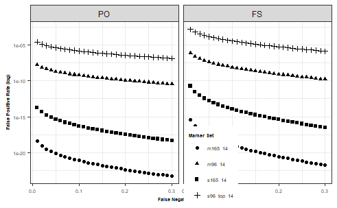

```r
FPR_ses_14 <- FPRs_etc_14 %>%
  mutate(se_lo = FPR - 2 * se,
       se_hi = FPR + 2 * se)
# create a factor for ordering the relationship type
FPRs_etc_14$pstar_f = factor(FPRs_etc_14$pstar, levels=c("PO","FS", "HS"))
# remove the HS rows and then plot that
f3_14 <- FPRs_etc_14 %>%
  filter(., pstar_f != "HS") %>%
  ggplot(., aes(x = FNR, y = FPR, shape = marker_set)) +
  geom_point() +
 #geom_segment(aes(x = FNR, y = se_lo, xend = FNR, yend = se_hi)) +  # these are basically invisible because they are so small
  facet_grid(. ~ pstar_f) +
  scale_y_continuous(trans = "log10") +
  xlab("False Negative Rate") +
  ylab("False Positive Rate (log)") +
  theme_bw()
fig3_14 <- f3_14 +
  guides(shape=guide_legend(title="Marker Set")) +
  theme(
  axis.text.x=element_text(size=5),
  axis.title.x=element_text(size=5, face="bold"),
  axis.text.y=element_text(size=5),
  axis.title.y=element_text(size=5, face="bold"),
  legend.text=element_text(size=5),
  legend.title=element_text(size=5, face="bold"))
fig3_14 <- fig3_14 +
  theme(legend.position = c(0.6, 0.1))
fig3_14
```